# Working from a phyloseq object

# 2. Composition

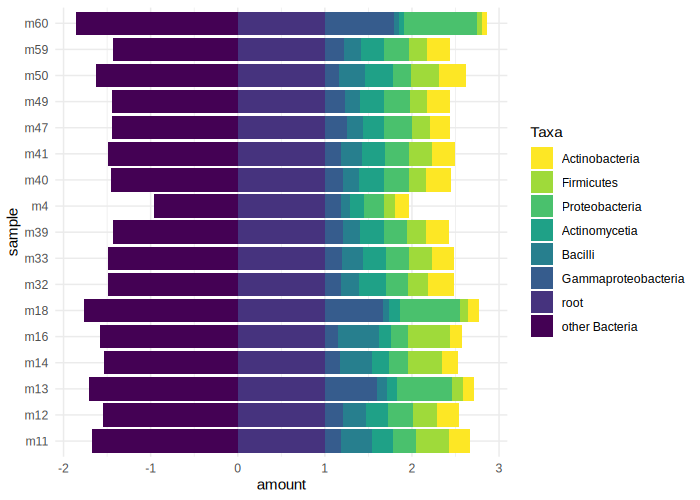

```r
psdf_top <- df_taxa_trim(psdf[psdf$clade != "S", ], top_taxa = 8)
df2composition(psdf_top)
```

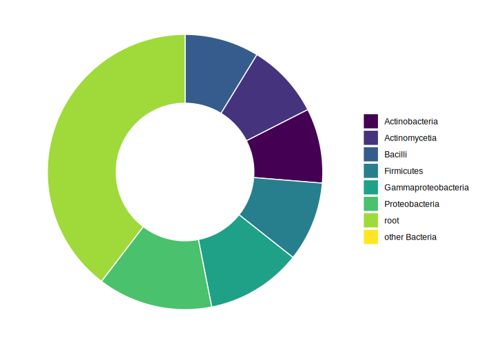

```r
df2donut(psdf_top)
```

# 3. Alpha diversity + statistics

We compute per-sample Shannon and Simpson indices from the species-level rows of the converted table and compare stages with a Wilcoxon test annotated by `ggpubr::stat_compare_means()` — viridis fills, light theme.

```r
psdf_sp <- psdf[psdf$clade == "S", ]
alpha_tab <- psdf_sp %>%
  dplyr::group_by(sample) %>%
  dplyr::summarise(
    Shannon = abdiv::shannon(N),
    Simpson = abdiv::simpson(N),
    .groups = "drop"
  )
alpha_tab <- dplyr::left_join(alpha_tab, meta, by = "sample")
alpha_long <- tidyr::pivot_longer(alpha_tab, c("Shannon", "Simpson"),
                                  names_to = "index", values_to = "value")
head(alpha_tab)
```

```
#> # A tibble: 6 × 5
#>   sample Shannon Simpson stage   hive
#>   <fct>    <dbl>   <dbl> <fct>  <int>
#> 1 m11       4.65   0.940 larvae     1
#> 2 m12       5.01   0.967 larvae     1
#> 3 m13       3.56   0.798 larvae     1
#> 4 m14       4.61   0.925 larvae     1
#> 5 m16       4.07   0.855 larvae     1
#> 6 m18       2.86   0.659 pupa       1
```

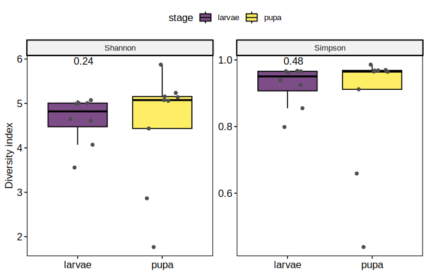

```r
ggpubr::ggboxplot(
  alpha_long, x = "stage", y = "value", fill = "stage",
  palette = viridis::viridis(2), alpha = 0.7,
  add = "jitter", add.params = list(color = "grey30", size = 1.5),
  facet.by = "index", scales = "free_y"
) +
  ggpubr::stat_compare_means(
    ggplot2::aes(label = ggplot2::after_stat(p.format)),
    method = "wilcox.test"
  ) +
  labs(x = NULL, y = "Diversity index")
```

# 4. Beta diversity directly on the phyloseq object

Because the beta-diversity functions call `as_samovar_df()` / `as_samovar_matrix()` internally, we can hand them the `phyloseq` object **directly**. `df2beta()` defaults to the genus clade, so `df2beta(ps, print_df = TRUE)` returns a genus-level Bray-Curtis distance matrix with no manual conversion.

```r
d <- stats::as.dist(df2beta(ps, print_df = TRUE))
grp <- meta$stage[match(labels(d), meta$sample)]
as.matrix(d)[1:4, 1:4]
```

```
#>           m11       m12       m13       m14
#> m11 0.0000000 0.2756527 0.5678842 0.2120245
#> m12 0.2756527 0.0000000 0.5450748 0.3461133
#> m13 0.5678842 0.5450748 0.0000000 0.5310940
#> m14 0.2120245 0.3461133 0.5310940 0.0000000
```

```r
set.seed(1)
vegan::adonis2(d ~ grp)
```

```
#> Permutation test for adonis under reduced model
#> Permutation: free
#> Number of permutations: 999
#>
#> vegan::adonis2(formula = d ~ grp)
#>          Df SumOfSqs      R2      F Pr(>F)
#> Model     1  0.16018 0.09374 1.5516  0.216
#> Residual 15  1.54850 0.90626
#> Total    16  1.70868 1.00000
```

A PCoA ordination, coloured by stage with grouping ellipses. Here we use the compositional (Aitchison) backend on the converted genus table when `robCompositions` is available, falling back to Bray-Curtis otherwise.

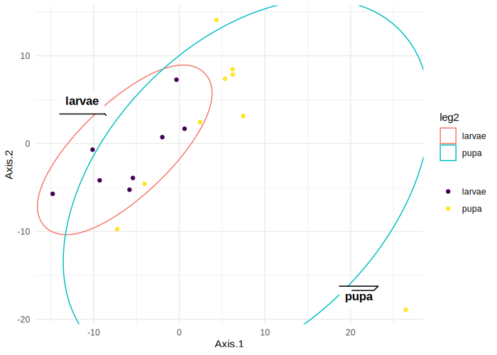

```r
psdf_g <- psdf[psdf$clade == "G", ]
beta_method <- if (requireNamespace("robCompositions", quietly = TRUE)) {
  "aitchison"
} else {
  "bray"
}
df2beta_pcoa(psdf_g, method = beta_method, add_legend = 7, add_ellipse = 7)
```

A polished version with `ggpubr::ggscatter()` (confidence ellipses, group means, viridis):

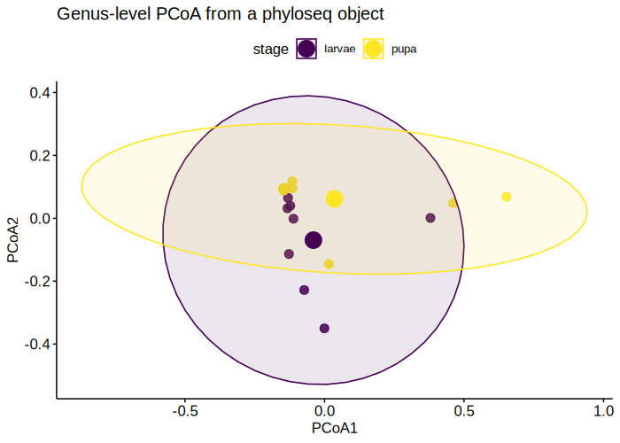

```r
pcoa <- ape::pcoa(as.matrix(df2beta(ps, print_df = TRUE)))
scores <- as.data.frame(pcoa$vectors[, 1:2])
names(scores) <- c("PCoA1", "PCoA2")
scores$sample <- rownames(scores)
scores <- dplyr::left_join(scores, meta, by = "sample")

ggpubr::ggscatter(
  scores, x = "PCoA1", y = "PCoA2",
  color = "stage", palette = viridis::viridis(2),
  ellipse = TRUE, ellipse.type = "norm", mean.point = TRUE,
  size = 3, alpha = 0.85
) +
  labs(title = "Genus-level PCoA from a phyloseq object")
```

# 5. Co-occurrence network directly on the phyloseq object

`df2graph()` / `df2ggraph()` also accept the `phyloseq` object directly (genus clade, top taxa by abundance), building the annotated `tidygraph` network and drawing it with the shared `ggraph` engine — communities in viridis.

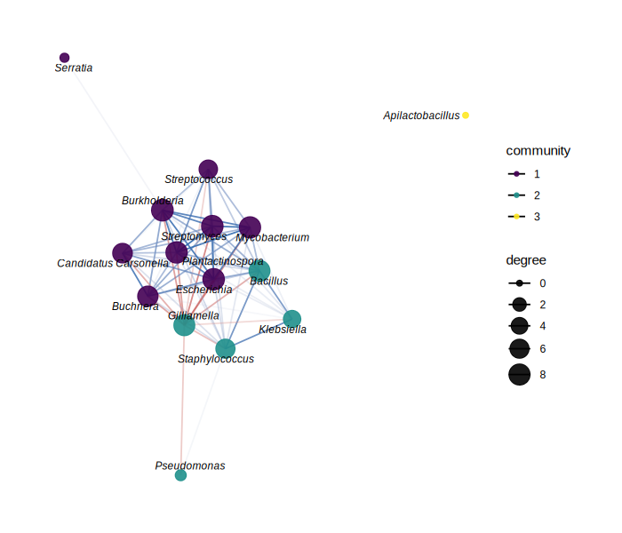

```r
set.seed(1)
df2ggraph(ps, top = 15, threshold = 0.3)
```

For NetCoMi-based association networks the `phyloseq` object works the same way via `df2netcomi()` / `df2netcomi_graph()`; that path needs the heavy optional `NetCoMi` dependency, so it is shown but not evaluated here.

```r
res <- df2netcomi(ps, top = 15, measure = "pearson", thresh = 0.3)
df2netcomi_graph(res, plot = TRUE)
```